# Raport - analiza rozmarów śledzi

Martin Berent

23.01.2016

### Streszczenie

Przedmiotem poniższej analizy jest określenie dlaczego długość śledzia oceanicznego wyławianego w Europie w pewnym momencie zaczeła spadać. W ramach analizy dysponowano ponad 52 tysiącami obserwacji dokonanych podczas połowów. Dla każdej obserwacji odnotowane zostały dane dotyczące dostępności planktonu, warunków środowiskowych oraz eksploatacji łowisk. Rozmiar śledzia określany był na podstawie próbki o rozmiarze od 50 do 100 trzy letnich śledzi.

W ramach raportu przedstawiono podstawowe statystyki dla każdej cechy. Dokonano szczegółowej analizy rozkładu danych, co pomogło w określeniu i usunięciu wartości odstających. W następnym kroku przeprowadzono inspekcję wartości pustych. Zbadano ich udział, rozkład oraz strukturę. Na tej podstawie użyto filtru Kalmana do wypełnienia wartości pustych. Po wstępnym przetwarzaniu danych przeanalizowano korelację cech. Zauważono że wielkość sledzia jest wysoce skorelowana z temperaturą przy powierzchni wody. Dodatkowo zobrazowano zależność wpływu oscylacji północnoatlantyckiej na dostępność planktonu Calanus helgolandicus gat. 1 i Widłonogów gat. 1. Dysponując danymi uszeregowanymi chronologicznie w następnym kroku podjęto próbę zobrazowania zależności czasowych dla trzech grup cech: dostępności planktonu, warunków środowiskowych oraz ekploatacji łowisk. Przedstawiono również zmianę rozmiarów śledzia na przestrzeni kolejnych połowów.

W ostatnim etapie zbudowano dwa modele regresji przewidujące rozmiar śledzia. Modele te zostały poddane ocenie R square oraz RMSE oraz porównane ze sobą. Dla każdego modelu określono ważność atrybutów. Wyniki te w dużym stopniu potwierdziły silną zalezność rozmiaru śledzia z temperatura przy powierzchni wody.

### Dane

#### Atrybuty

- **length:** długość złowionego śledzia [cm]
- **cfin1:** dostępność planktonu [zagęszczenie Calanus finmarchicus gat. 1]
- **cfin2:** dostępność planktonu [zagęszczenie Calanus finmarchicus gat. 2]
- **chel1:** *dostępność planktonu [zagęszczenie Calanus helgolandicus gat. 1]
- **chel2:** dostępność planktonu [zagęszczenie Calanus helgolandicus gat. 2]
- **lcop1:** dostępność planktonu [zagęszczenie Widłonogów gat. 1]
- **lcop2:** dostępność planktonu [zagęszczenie Widłonogów gat. 2]
- **fbar:** natężenie połowów w regionie [ułamek pozostawionego narybku]
- **recr:** roczny narybek [liczba śledzi]
- **cumf:** łączne roczne natężenie połowów w regionie [ułamek pozostawionego narybku]
- **totaln:** łączna liczba ryb złowionych w ramach połowu [liczba śledzi]
- **sst:** temperatura przy powierzchni wody [°C]
- **sal:** poziom zasolenia wody [Knudsen ppt]
- **xmonth:** miesiąc połowu [numer miesiąca]
- **nao:** oscylacja północnoatlantycka [mb]

#### Pierwszych pięć obserwacji

```r
data <- read.csv("sledzie.csv", header = TRUE, sep = ",", na.strings = "?", nrows=52581)
data$xmonth <- factor(data$xmonth, sort(as.numeric(unique(data$xmonth))))
data <- data %>% rename(fishing = X)
pander(head(data))
```

| fishing | length | cfin1 | cfin2 | chel1 | chel2 | lcop1 | lcop2 | fbar | recr | cumf | totaln | sst | sal | xmonth | nao |
| --- | --- | --- | --- | --- | --- | --- | --- | --- | --- | --- | --- | --- | --- | --- | --- |
| 0 | 23 | 0.02778 | 0.2778 | 2.469 | NA | 2.548 | 26.36 | 0.356 | 482831 | 0.306 | 267381 | 14.31 | 35.51 | 7 | 2.8 |
| 1 | 22.5 | 0.02778 | 0.2778 | 2.469 | 21.44 | 2.548 | 26.36 | 0.356 | 482831 | 0.306 | 267381 | 14.31 | 35.51 | 7 | 2.8 |
| 2 | 25 | 0.02778 | 0.2778 | 2.469 | 21.44 | 2.548 | 26.36 | 0.356 | 482831 | 0.306 | 267381 | 14.31 | 35.51 | 7 | 2.8 |
| 3 | 25.5 | 0.02778 | 0.2778 | 2.469 | 21.44 | 2.548 | 26.36 | 0.356 | 482831 | 0.306 | 267381 | 14.31 | 35.51 | 7 | 2.8 |
| 4 | 24 | 0.02778 | 0.2778 | 2.469 | 21.44 | 2.548 | 26.36 | 0.356 | 482831 | 0.306 | 267381 | 14.31 | 35.51 | 7 | 2.8 |
| 5 | 22 | 0.02778 | 0.2778 | 2.469 | 21.44 | 2.548 | NA | 0.356 | 482831 | 0.306 | 267381 | 14.31 | 35.51 | 7 | 2.8 |

### Podstawowe statystyki

#### Podsumowanie cech

```r
sprintf("Liczba kolumn %d", ncol(data))
```

```
## [1] "Liczba kolumn 16"
```

```r
sprintf("Liczba wierszy %d", nrow(data))
```

```
## [1] "Liczba wierszy 52581"
```

```r
sprintf("Liczba wierszy nie zawierających wartości pustej %d", nrow(na.omit(data)))
```

```
## [1] "Liczba wierszy nie zawierających wartości pustej 42488"
```

```r
pander(summary(data))
```

Table continues below

| fishing | length | cfin1 | cfin2 | chel1 | chel2 | lcop1 | lcop2 | fbar |
| --- | --- | --- | --- | --- | --- | --- | --- | --- |
| Min. : 0 | Min. :19.0 | Min. : 0.0000 | Min. : 0.0000 | Min. : 0.000 | Min. : 5.238 | Min. : 0.3074 | Min. : 7.849 | Min. :0.0680 |
| 1st Qu.:13145 | 1st Qu.:24.0 | 1st Qu.: 0.0000 | 1st Qu.: 0.2778 | 1st Qu.: 2.469 | 1st Qu.:13.427 | 1st Qu.: 2.5479 | 1st Qu.:17.808 | 1st Qu.:0.2270 |
| Median :26290 | Median :25.5 | Median : 0.1111 | Median : 0.7012 | Median : 5.750 | Median :21.673 | Median : 7.0000 | Median :24.859 | Median :0.3320 |
| Mean :26290 | Mean :25.3 | Mean : 0.4458 | Mean : 2.0248 | Mean :10.006 | Mean :21.221 | Mean : 12.8108 | Mean :28.419 | Mean :0.3303 |
| 3rd Qu.:39435 | 3rd Qu.:26.5 | 3rd Qu.: 0.3333 | 3rd Qu.: 1.7936 | 3rd Qu.:11.500 | 3rd Qu.:27.193 | 3rd Qu.: 21.2315 | 3rd Qu.:37.232 | 3rd Qu.:0.4560 |
| Max. :52580 | Max. :32.5 | Max. :37.6667 | Max. :19.3958 | Max. :75.000 | Max. :57.706 | Max. :115.5833 | Max. :68.736 | Max. :0.8490 |
| NA | NA | NA’s :1581 | NA’s :1536 | NA’s :1555 | NA’s :1556 | NA’s :1652 | NA’s :1591 | NA |

| recr | cumf | totaln | sst | sal | xmonth | nao |
| --- | --- | --- | --- | --- | --- | --- |
| Min. : 140515 | Min. :0.06833 | Min. : 144137 | Min. :12.77 | Min. :35.40 | 8 : 9920 | Min. :-4.89000 |
| 1st Qu.: 360061 | 1st Qu.:0.14809 | 1st Qu.: 306068 | 1st Qu.:13.60 | 1st Qu.:35.51 | 10 : 7972 | 1st Qu.:-1.89000 |
| Median : 421391 | Median :0.23191 | Median : 539558 | Median :13.86 | Median :35.51 | 7 : 6922 | Median : 0.20000 |
| Mean : 520368 | Mean :0.22981 | Mean : 514979 | Mean :13.87 | Mean :35.51 | 9 : 5714 | Mean :-0.09233 |
| 3rd Qu.: 724151 | 3rd Qu.:0.29803 | 3rd Qu.: 730351 | 3rd Qu.:14.16 | 3rd Qu.:35.52 | 6 : 4217 | 3rd Qu.: 1.63000 |
| Max. :1565890 | Max. :0.39801 | Max. :1015595 | Max. :14.73 | Max. :35.61 | 5 : 3736 | Max. : 5.08000 |
| NA | NA | NA | NA’s :1584 | NA | (Other):14100 | NA |

#### Rozkład wartości cech

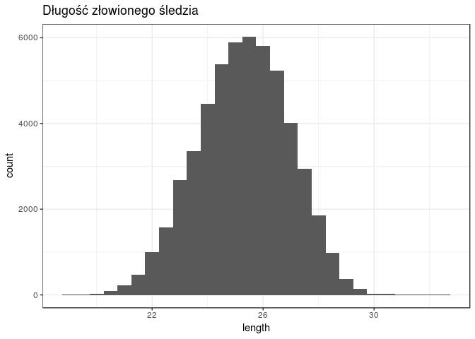

```r
ggplot(data, aes(length)) + geom_histogram(binwidth = 0.5) +
  theme_bw() + ggtitle('Długość złowionego śledzia')
```

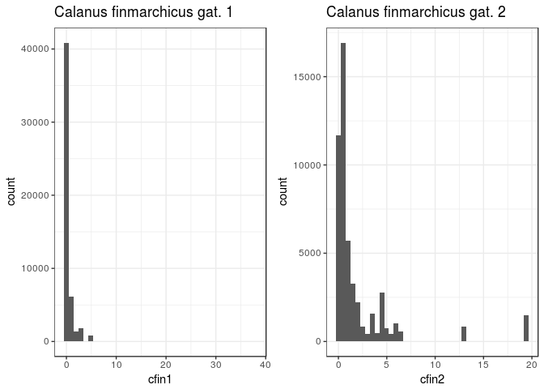

```r
p_cfin1 <- ggplot(data, aes(cfin1)) + geom_histogram(bins = 40) +
  theme_bw() + ggtitle('Calanus finmarchicus gat. 1')
p_cfin2 <- ggplot(data, aes(cfin2)) + geom_histogram(bins = 40) +
  theme_bw() + ggtitle('Calanus finmarchicus gat. 2')
grid.arrange(p_cfin1, p_cfin2, nrow=1)
```

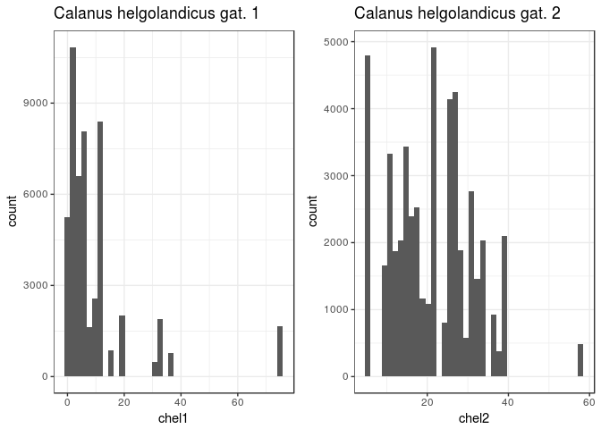

```r
p_chel1 <- ggplot(data, aes(chel1)) + geom_histogram(bins = 40) +
  theme_bw() + ggtitle('Calanus helgolandicus gat. 1')
p_chel2 <- ggplot(data, aes(chel2)) + geom_histogram(bins = 40) +
  theme_bw() + ggtitle('Calanus helgolandicus gat. 2')
grid.arrange(p_chel1, p_chel2, nrow=1)
```

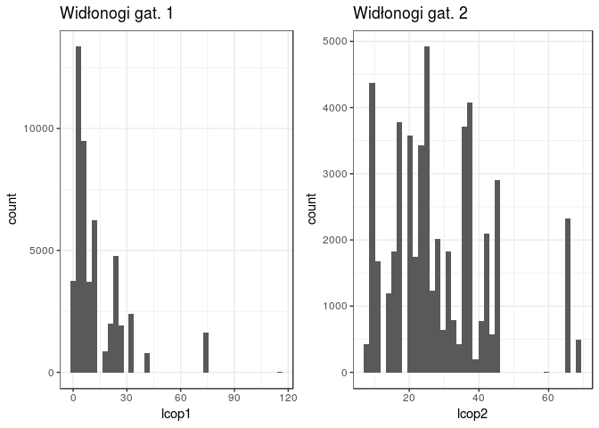

```r
p_lcop1 <- ggplot(data, aes(lcop1)) + geom_histogram(bins = 40) +
  theme_bw() + ggtitle('Widłonogi gat. 1')
p_lcop2 <- ggplot(data, aes(lcop2)) + geom_histogram(bins = 40) +
  theme_bw()+ ggtitle('Widłonogi gat. 2')
grid.arrange(p_lcop1, p_lcop2, nrow=1)
```

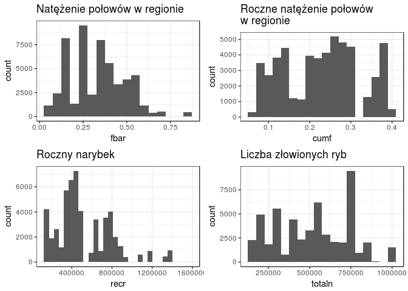

```r
p_fbar <- ggplot(data, aes(fbar)) + geom_histogram(binwidth = 0.05) +
  theme_bw() + ggtitle('Natężenie połowów w regionie')
p_cumf <- ggplot(data, aes(cumf)) + geom_histogram(binwidth = 0.02) +
  theme_bw() + ggtitle('Roczne natężenie połowów\nw regionie')
p_recr <- ggplot(data, aes(recr)) + geom_histogram() +
  theme_bw() + ggtitle('Roczny narybek')
p_totaln <- ggplot(data, aes(totaln)) + geom_histogram(binwidth = 50000) +
  theme_bw() + ggtitle('Liczba złowionych ryb')
grid.arrange(p_fbar, p_cumf, p_recr, p_totaln, nrow=2)
```

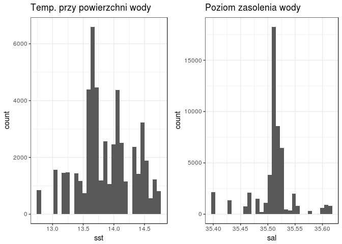

```r
p_sst <- ggplot(data, aes(sst)) + geom_histogram() +
  theme_bw() + ggtitle('Temp. przy powierzchni wody')
p_sal <- ggplot(data, aes(sal)) + geom_histogram() +
  theme_bw() + ggtitle('Poziom zasolenia wody')
grid.arrange(p_sst, p_sal, nrow=1)
```

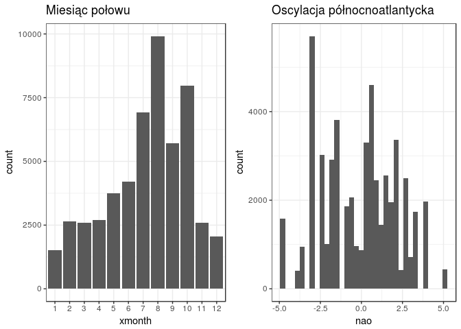

```r
p_xmonth <- ggplot(data, aes(xmonth)) + geom_bar(stat = 'count') +
  theme_bw() + ggtitle('Miesiąc połowu')
p_nao <- ggplot(data, aes(nao)) + geom_histogram(binwidth = 0.3) +
  theme_bw() + ggtitle('Oscylacja północnoatlantycka')
grid.arrange(p_xmonth, p_nao, nrow=1)
```

### Wartości odstające

Na podstawie wykresów obrazujących rozkład wartości można wnioskować że dla atrybutów *cfin1* oraz *lcop1* występują wartości odstające.

```r
pander(data %>% filter(cfin1 > 10 | lcop1 > 90))
```

| fishing | length | cfin1 | cfin2 | chel1 | chel2 | lcop1 | lcop2 | fbar | recr | cumf | totaln | sst | sal | xmonth | nao |
| --- | --- | --- | --- | --- | --- | --- | --- | --- | --- | --- | --- | --- | --- | --- | --- |
| 52496 | 28 | 37.67 | 10.17 | 64.75 | 43.64 | 115.6 | 59.09 | 0.125 | 1565890 | 0.09586 | 727441 | 13.62 | 35.53 | 9 | -1.02 |
| 52497 | 24.5 | 37.67 | 10.17 | 64.75 | 43.64 | 115.6 | 59.09 | 0.125 | 1565890 | 0.09586 | 727441 | 13.62 | 35.53 | 9 | -1.02 |
| 52498 | 27 | 37.67 | 10.17 | 64.75 | 43.64 | 115.6 | 59.09 | 0.125 | 1565890 | 0.09586 | 727441 | 13.62 | 35.53 | 9 | -1.02 |
| 52499 | 26 | 37.67 | 10.17 | 64.75 | 43.64 | 115.6 | 59.09 | 0.125 | 1565890 | 0.09586 | 727441 | 13.62 | 35.53 | 9 | -1.02 |
| 52500 | 25.5 | 37.67 | 10.17 | 64.75 | 43.64 | 115.6 | 59.09 | 0.125 | 1565890 | 0.09586 | 727441 | 13.62 | 35.53 | 9 | -1.02 |
| 52501 | 24.5 | 37.67 | 10.17 | 64.75 | 43.64 | 115.6 | 59.09 | 0.125 | 1565890 | 0.09586 | 727441 | 13.62 | 35.53 | 9 | -1.02 |

Powyższe obserwacje zostaną usunięte ze zbioru danych. Poniżej rozkład wartości bez wartości odstających.

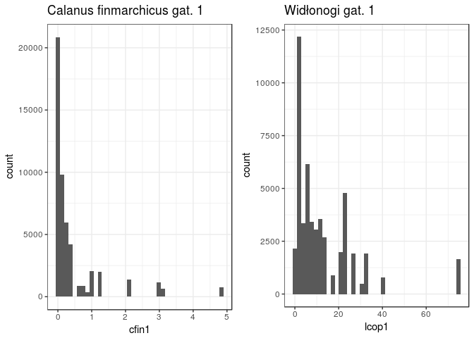

```r
data <- data %>% filter(cfin1 <= 10 | is.na(cfin1)) %>% filter(lcop1 <= 90 | is.na(lcop1))

p_cfin1 <- ggplot(data, aes(cfin1)) + geom_histogram(bins = 40) +
  theme_bw() + ggtitle('Calanus finmarchicus gat. 1')
p_lcop1 <- ggplot(data, aes(lcop1)) + geom_histogram(bins = 40) +
  theme_bw() + ggtitle('Widłonogi gat. 1')

grid.arrange(p_cfin1, p_lcop1, nrow=1)
```

### Wartości puste

Kolumny zawierające wartości puste wraz z analizą udziału, rozkładu oraz struktury.

```r
colnames(data)[apply(is.na(data), 2, any)]
```

```
## [1] "cfin1" "cfin2" "chel1" "chel2" "lcop1" "lcop2" "sst"
```

#### cfin1

```r
statsNA(data$cfin1, bins = 10)
```

```
## [1] "Length of time series:"
## [1] 52575
## [1] "-------------------------"
## [1] "Number of Missing Values:"
## [1] 1581
## [1] "-------------------------"
## [1] "Percentage of Missing Values:"
## [1] "3.01%"
## [1] "-------------------------"
## [1] "Stats for Bins"
## [1] "  Bin 1 (5258 values from 1 to 5258) :      159 NAs (3.02%)"
## [1] "  Bin 2 (5258 values from 5259 to 10516) :      144 NAs (2.74%)"
## [1] "  Bin 3 (5258 values from 10517 to 15774) :      172 NAs (3.27%)"
## [1] "  Bin 4 (5258 values from 15775 to 21032) :      168 NAs (3.2%)"
## [1] "  Bin 5 (5258 values from 21033 to 26290) :      153 NAs (2.91%)"
```

[output cut: 19 more lines]

#### cfin2

```r
statsNA(data$cfin2, bins = 10)
```

```
## [1] "Length of time series:"
## [1] 52575
## [1] "-------------------------"
## [1] "Number of Missing Values:"
## [1] 1536
## [1] "-------------------------"
## [1] "Percentage of Missing Values:"
## [1] "2.92%"
## [1] "-------------------------"
## [1] "Stats for Bins"
## [1] "  Bin 1 (5258 values from 1 to 5258) :      162 NAs (3.08%)"
## [1] "  Bin 2 (5258 values from 5259 to 10516) :      150 NAs (2.85%)"
## [1] "  Bin 3 (5258 values from 10517 to 15774) :      157 NAs (2.99%)"
## [1] "  Bin 4 (5258 values from 15775 to 21032) :      134 NAs (2.55%)"
## [1] "  Bin 5 (5258 values from 21033 to 26290) :      154 NAs (2.93%)"
```

[output cut: 19 more lines]

#### chel1

```r
statsNA(data$chel1, bins = 10)
```

```
## [1] "Length of time series:"
## [1] 52575
## [1] "-------------------------"
## [1] "Number of Missing Values:"
## [1] 1555
## [1] "-------------------------"
## [1] "Percentage of Missing Values:"
## [1] "2.96%"
## [1] "-------------------------"
## [1] "Stats for Bins"
## [1] "  Bin 1 (5258 values from 1 to 5258) :      138 NAs (2.62%)"
## [1] "  Bin 2 (5258 values from 5259 to 10516) :      158 NAs (3%)"
## [1] "  Bin 3 (5258 values from 10517 to 15774) :      168 NAs (3.2%)"
## [1] "  Bin 4 (5258 values from 15775 to 21032) :      173 NAs (3.29%)"
## [1] "  Bin 5 (5258 values from 21033 to 26290) :      143 NAs (2.72%)"
```

[output cut: 19 more lines]

#### chel2

```r
statsNA(data$chel2, bins = 10)
```

```
## [1] "Length of time series:"
## [1] 52575
## [1] "-------------------------"
## [1] "Number of Missing Values:"
## [1] 1556
## [1] "-------------------------"
## [1] "Percentage of Missing Values:"
## [1] "2.96%"
## [1] "-------------------------"
## [1] "Stats for Bins"
## [1] "  Bin 1 (5258 values from 1 to 5258) :      159 NAs (3.02%)"
## [1] "  Bin 2 (5258 values from 5259 to 10516) :      161 NAs (3.06%)"
## [1] "  Bin 3 (5258 values from 10517 to 15774) :      158 NAs (3%)"
## [1] "  Bin 4 (5258 values from 15775 to 21032) :      173 NAs (3.29%)"
## [1] "  Bin 5 (5258 values from 21033 to 26290) :      151 NAs (2.87%)"
```

[output cut: 19 more lines]

#### lcop1

```r
statsNA(data$lcop1, bins = 10)
```

```
## [1] "Length of time series:"
## [1] 52575
## [1] "-------------------------"
## [1] "Number of Missing Values:"
## [1] 1652
## [1] "-------------------------"
## [1] "Percentage of Missing Values:"
## [1] "3.14%"
## [1] "-------------------------"
## [1] "Stats for Bins"
## [1] "  Bin 1 (5258 values from 1 to 5258) :      177 NAs (3.37%)"
## [1] "  Bin 2 (5258 values from 5259 to 10516) :      189 NAs (3.59%)"
## [1] "  Bin 3 (5258 values from 10517 to 15774) :      144 NAs (2.74%)"
## [1] "  Bin 4 (5258 values from 15775 to 21032) :      148 NAs (2.81%)"
## [1] "  Bin 5 (5258 values from 21033 to 26290) :      160 NAs (3.04%)"
```

[output cut: 18 more lines]

#### lcop2

```r
statsNA(data$lcop2, bins = 10)
```

```
## [1] "Length of time series:"
## [1] 52575
## [1] "-------------------------"
## [1] "Number of Missing Values:"
## [1] 1591
## [1] "-------------------------"
## [1] "Percentage of Missing Values:"
## [1] "3.03%"
## [1] "-------------------------"
## [1] "Stats for Bins"
## [1] "  Bin 1 (5258 values from 1 to 5258) :      154 NAs (2.93%)"
## [1] "  Bin 2 (5258 values from 5259 to 10516) :      165 NAs (3.14%)"
## [1] "  Bin 3 (5258 values from 10517 to 15774) :      181 NAs (3.44%)"
## [1] "  Bin 4 (5258 values from 15775 to 21032) :      162 NAs (3.08%)"
## [1] "  Bin 5 (5258 values from 21033 to 26290) :      147 NAs (2.8%)"
```

[output cut: 19 more lines]

#### sst

```r
statsNA(data$sst, bins = 10)
```

```
## [1] "Length of time series:"
## [1] 52575
## [1] "-------------------------"
## [1] "Number of Missing Values:"
## [1] 1584
## [1] "-------------------------"
## [1] "Percentage of Missing Values:"
## [1] "3.01%"
## [1] "-------------------------"
## [1] "Stats for Bins"
## [1] "  Bin 1 (5258 values from 1 to 5258) :      162 NAs (3.08%)"
## [1] "  Bin 2 (5258 values from 5259 to 10516) :      159 NAs (3.02%)"
## [1] "  Bin 3 (5258 values from 10517 to 15774) :      153 NAs (2.91%)"
## [1] "  Bin 4 (5258 values from 15775 to 21032) :      160 NAs (3.04%)"
## [1] "  Bin 5 (5258 values from 21033 to 26290) :      141 NAs (2.68%)"
```

[output cut: 19 more lines]

#### Wypełnianie wartości pustych

Dla wszystkich powyższych atrubutów wartości puste stanowią mniej niż 5% obserwacji. Ich rokład jest równomierny i ma charakter losowy. Sekwencje dwóch lub trzech wartości pustych są rzadkie. W związku z tym wartości puste będą imputowane z użyciem filtru Kalmana.

```r
data$cfin1 <- na.kalman(data$cfin1)
data$cfin2 <- na.kalman(data$cfin2)
data$chel1 <- na.kalman(data$chel1)
data$chel2 <- na.kalman(data$chel2)
data$lcop1 <- na.kalman(data$lcop1)
data$lcop2 <- na.kalman(data$lcop2)
data$sst <- na.kalman(data$sst)
```

### Korelacja

Do przygotowania wykresu nie użyto kolumny identyfikującej połów oraz kolumny określającej miesiąc połowu.

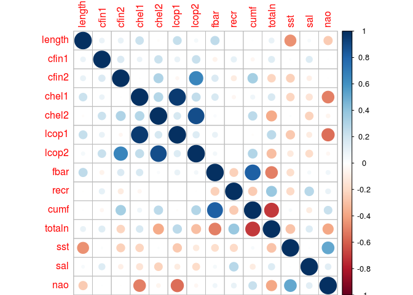

```r
M<-cor(data[, -c(1,15)])
corrplot(M, method="circle")
```

Silna zalezność rozmiaru śledzia i temperatury przy powierzchni wody przedstawiona z użyciem lini trendu. Można wnioskować że większa temperatura ma odzwierciedlenie w mniejszych rozmiarach złowionych śledzi.

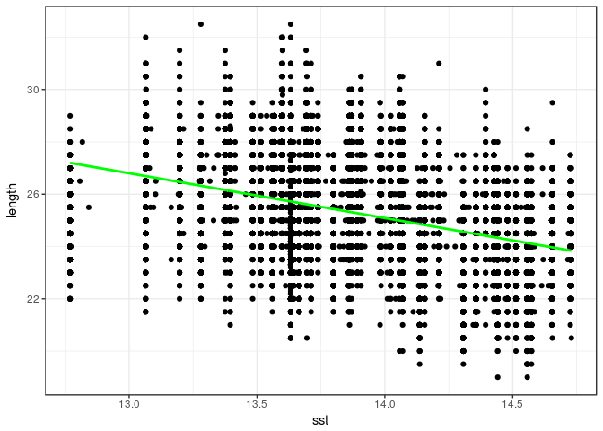

```r
data_sample <- data
ggplot(data_sample, aes(sst, length)) +
  geom_point() +
  geom_smooth(color="green", method="lm") +
  theme_bw()
```

Na podstawie korelacji można zauważyć również zalezność pomiędzy dostępnością **chel1** Calanus helgolandicus gat. 1 i **lcop1:** Widłonogów gat. 1 a **nao** oscylacją pólnocnoatlantydzką.

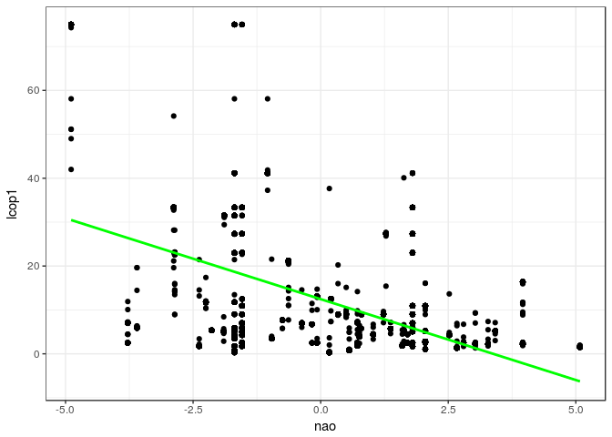

```r
data_sample <- data
ggplot(data_sample, aes(nao, lcop1)) +
  geom_point() +
  geom_smooth(color="green", method="lm") +
  theme_bw()
```

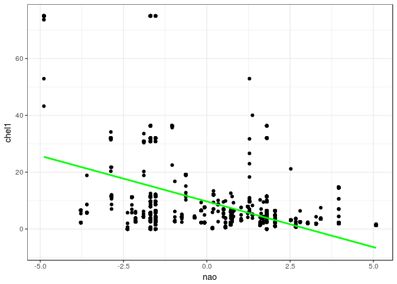

```r
data_sample <- data
ggplot(data_sample, aes(nao, chel1)) +
  geom_point() +
  geom_smooth(color="green", method="lm") +
  theme_bw()
```

### Zmienność cech w kolejnych połowach

Szarą przerywaną linią oznaczono połów rozpoczynający zmianę trendu długości złowionego śledzia.

```r
data_sample <- sample_n(data, 500)
q <- ggplot(data_sample, aes(fishing, length)) +
  geom_jitter() +
  geom_smooth(se = FALSE, color="green") +
  geom_vline(xintercept = 17000, colour="darkgray", linetype = "longdash", size=1) +
  ggtitle('Zmiana długości złowionego śledzia') +
  theme_bw()
ggplotly(q)
```

[interactive chart not shown]

Zmianą trendu długości śledzia poprzedza zmiana trendu dostępności Calanus helgolandicus gat. 1 i Widłonogów gat. 1

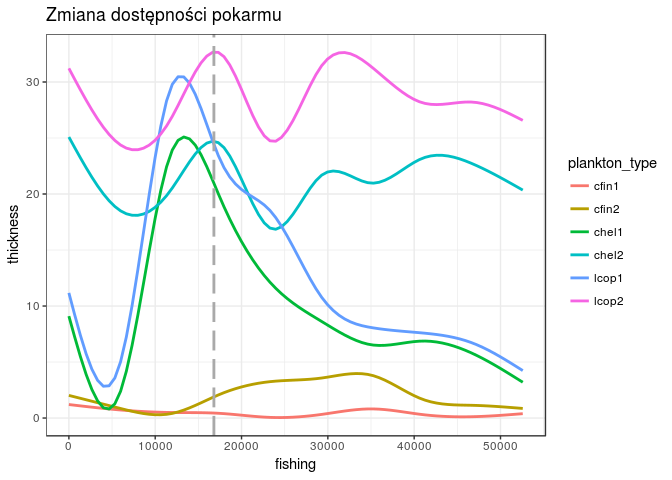

```r
food <- melt(data[, c(1, 3:8)], id.vars = c('fishing'),  variable.name = "plankton_type", value.name = "thickness")
ggplot(food, aes(fishing, thickness, color=plankton_type)) +
  geom_smooth(se = FALSE) +
  geom_vline(xintercept = 16800, colour="darkgray", linetype = "longdash", size=1) +
  ggtitle('Zmiana dostępności pokarmu') +
  theme_bw()
```

Przed zmiana trendu długości śledzia widać duży spadek oscylacji północno atlantydzkiej. Dodatkowo po zmianie trendu zaobserwować można sukcesywny wzrost temperatury przy powierzchni wody.

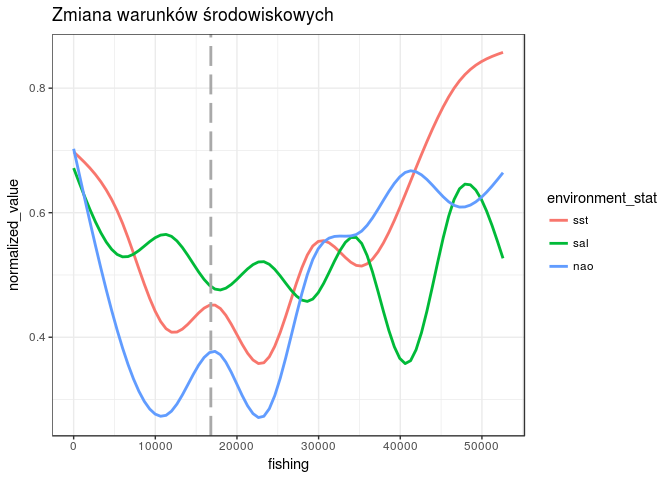

```r
environment <- data[, c('sst', 'sal', 'nao')]
normed <- as.data.frame(lapply(environment, minMaxNormalization))
normed["fishing"] <- data$fishing
environment_melt <- melt(normed, id.vars = c('fishing'),  variable.name = "environment_stat", value.name = "normalized_value")

ggplot(environment_melt, aes(fishing, normalized_value, color=environment_stat)) +
  geom_smooth(se = FALSE) +
  geom_vline(xintercept = 16800, colour="darkgray", linetype = "longdash", size=1) +
  ggtitle('Zmiana warunków środowiskowych') +
  theme_bw()
```

Przed zmianą trendu rozmiaru śledzia widoczne są duże zmiany w eksploatacji i kondycji łowisk.

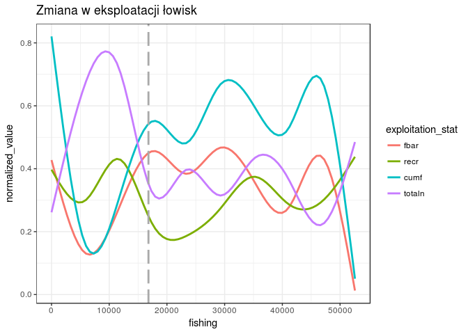

```r
exploitation <- data[, c('fbar', 'recr', 'cumf', 'totaln')]
normed <- as.data.frame(lapply(exploitation, minMaxNormalization))
normed["fishing"] <- data$fishing
exploitation_melt <- melt(normed, id.vars = c('fishing'),  variable.name = "exploitation_stat", value.name = "normalized_value")

ggplot(exploitation_melt, aes(fishing, normalized_value, color=exploitation_stat)) +
  geom_smooth(se = FALSE) +
  geom_vline(xintercept = 16800, colour="darkgray", linetype = "longdash", size=1) +
  ggtitle('Zmiana w eksploatacji łowisk') +
  theme_bw()
```

### Regresja

#### Regresja liniowa

```r
ctrl <- trainControl(
  method="cv",
  number = 5)

model_lm <- train(length ~ ., data = X, method = "lm", trControl = ctrl)

print(model_lm)
```

```
## Linear Regression
##
## 52575 samples
##    14 predictors
##
## No pre-processing
## Resampling: Cross-Validated (5 fold)
## Summary of sample sizes: 42059, 42060, 42060, 42061, 42060
## Resampling results:
##
##   RMSE     Rsquared
##   1.34937  0.3336002
##
## Tuning parameter 'intercept' was held constant at a value of TRUE
##
```

Ocena wanożności atrybutów:

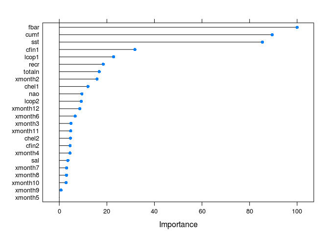

```r
plot(varImp(model_lm))
```

#### XgbLinear

```r
xgb_grid_1 = expand.grid(
  nrounds=c(20, 50, 100),
  eta=0.3,
  alpha=c(1,0.7,0.3,0.1,0),
  lambda=c(1,0.7,0.3,0.1,0)
)

ctrl <- trainControl(
  method="cv",
  number = 5,
  allowParallel = TRUE)

model_xgb <- train(length ~ ., data = X, trControl = ctrl,
                   tuneGrid = xgb_grid_1, method = "xgbLinear", max_depth = 5)

print(model_xgb)
```

```
## eXtreme Gradient Boosting
##
## 52575 samples
##    14 predictors
##
## No pre-processing
## Resampling: Cross-Validated (5 fold)
## Summary of sample sizes: 42059, 42061, 42059, 42061, 42060
## Resampling results across tuning parameters:
##
##   nrounds  alpha  lambda  RMSE      Rsquared
##    20      0.0    0.0     1.150602  0.5158291
##    20      0.0    0.1     1.149652  0.5166023
##    20      0.0    0.3     1.149896  0.5164486
##    20      0.0    0.7     1.153999  0.5130512
```

[output cut: 76 more lines]

Dobór parametrów modelu:

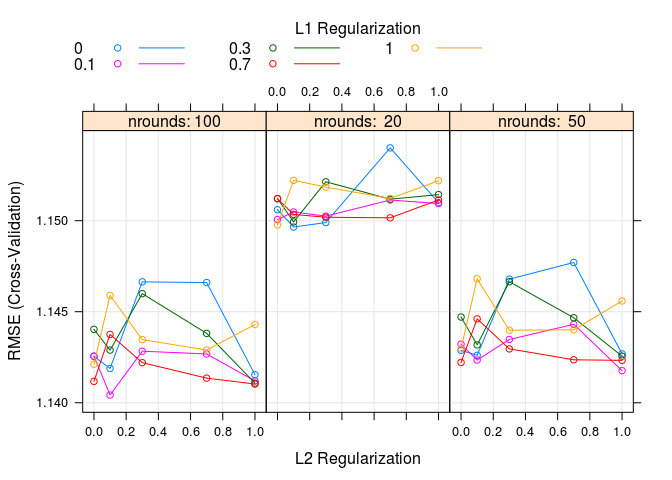

```r
plot(model_xgb)
```

Ocena wanożności atrybutów:

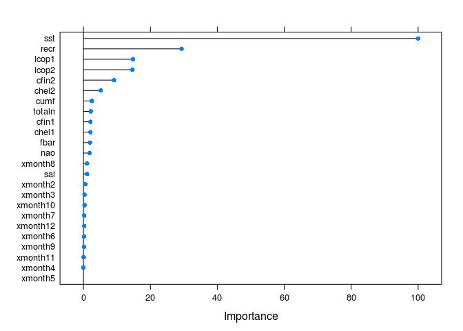

```r
plot(varImp(model_xgb))
```

#### Porównanie modeli i wnioski końcowe

Do porównania modeli użyto miary RMSE. Im mniejsza wartość tym lepszy regresor. W zestaieniu bezsprzecznie wygrywa model xgbLinear. Biorąc pod uwagę ten fakt oraz ocenę ważności atrybutów dla tego modelu można potwierdzić wczesniej zauważoną zależność. Zmiana temperatury przy powierzni ma znaczący i bezpośredni wpływ na zmianę wielkości śledzia w czasie. Natomiast zmiana dostępności pokarmu i ogólna liczba śledzi mogła być bezpośrednią przyczyną zmiany trendu rozmiaru śledzia.

```r
models <- list(lm = model_lm, xgb = model_xgb)
resampled <- resamples(models)

summary(resampled)
```

```
##
## Call:
## summary.resamples(object = resampled)
##
## Models: lm, xgb
## Number of resamples: 5
##
## RMSE
##      Min. 1st Qu. Median  Mean 3rd Qu.  Max. NA's
## lm  1.346   1.347  1.347 1.349   1.351 1.355    0
## xgb 1.128   1.130  1.138 1.140   1.149 1.157    0
##
## Rsquared
##       Min. 1st Qu. Median   Mean 3rd Qu.   Max. NA's
## lm  0.3241  0.3309 0.3366 0.3336  0.3372 0.3392    0
## xgb 0.5128  0.5191 0.5273 0.5239  0.5283 0.5323    0
```

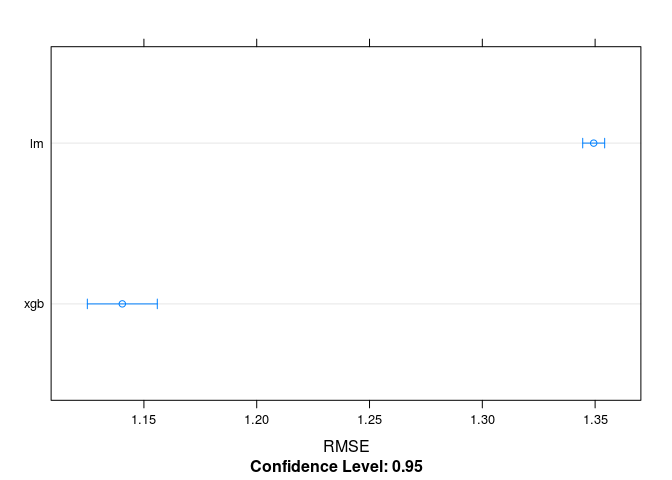

```r
dotplot(resampled, metric = "RMSE")
```